# Introduction to echor

Michael Schramm

2021-08-20

## echor introduction

`echor` is an R package to search and download data from the US Environmental Protection Agency (EPA) Environmental Compliance and History Online (ECHO). `echor` uses the [ECHO API](https://echo.epa.gov/) to download data directly to the R as dataframes or simple features. ECHO provides information about facilities permitted to emitted air pollutants or discharge into water bodies. ECHO also provides data reported by permitted facilities as volume or concentration of pollutants during reporting time periods (typically annually for air emissions and monthly or quarterly for water discharges).

ECHO provides data for:

- Stationary sources permitted under the Clean Air Act, including data from the National Emissions Inventory, Greenhouse Gas Reporting Program, Toxics Release Inventory, and Clean Air Markets Division Acid Rain Program and Clean Air Interstate Rule.
- Public drinking water systems permitted under the Safe Drinking Water Act, including data from the Safe Drinking Water Information System.
- Hazardous Waste Handlers permitted under the Resource Conservation and Recovery Act, with data drawn from the RCRAInfo data system.
- Facilities permitted under the Clean Water Act and the National Pollutant Discharge Elimination Systems (NPDES) program, including data from EPA’s ICIS-NPDES system and possibly water body information from EPA’s ATTAINS data system.

`echor` currently provides functions to retrieve information about permitted air dischargers, water dischargers, and public drinking water supply systems. It also provides functions to download discharge reports for permitted air and water dischargers. `echor` does not currently provide functionality to retrieve RCRA data.

See https://echo.epa.gov/tools/web-services for information about ECHO web services and API functions.

## Getting started

This vignette documents a few key functions to get started.

There are three types of functions:

### Metadata

Retrieve metadata from ECHO to narrow the specify data returned or lookup parameter codes.

- `echoAirGetMeta()` - Returns variable name and descriptions for parameters returned in air facility queries.
- `echoSDWGetMeta()` - Returns variable name and descriptions for parameters returned in public water system queries.
- `echoWaterGetMeta()` - Returns variable name and descriptions for parameters returned in water discharge facility queries (e.g. facilities with an NPDES permit).
- `echoWaterGetParams()` - Search parameter codes for constituent pollutants regulated under NPDES permits.

### Query Facilities

Search and return facility information based on lookup parameters.

### Reports

Search and return discharge and emissions reports for specified facilities.

- `echoGetCAAPR()` - Returns a dataframe with reported annual air emissions from permitted facilities.
- `echoGetEffluent()` - Returns a dataframe with reported water effluent discharges from permitted facilities.

## Sample workflows

### Air

Suppose we want to find facilities permitted under the Clean Air Act requirements.

Step 1 - Identify the information we need returned from the query:

```r
library(echor)
meta <- echoAirGetMeta()
meta
```

```
#> # A tibble: 144 x 6
#>    ColumnName                DataType DataLength ColumnID ObjectName Description
#>    <chr>                     <chr>    <chr>      <chr>    <chr>      <chr>
#>  1 AIR_NAME                  VARCHAR2 200        1        AIRName    The name o~
#>  2 SOURCE_ID                 VARCHAR2 30         2        SourceID   Unique Ide~
#>  3 AIR_STREET                VARCHAR2 200        3        AIRStreet  The street~
#>  4 AIR_CITY                  VARCHAR2 100        4        AIRCity    The city w~
#>  5 AIR_STATE                 CHAR     2          5        AIRState   The state ~
#>  6 LOCAL_CONTROL_REGION_CODE CHAR     3          6        LocalCont~ Code for r~
#>  7 AIR_ZIP                   VARCHAR2 10         7        AIRZip     The five-d~
#>  8 REGISTRY_ID               VARCHAR2 50         8        RegistryID An interna~
#>  9 AIR_COUNTY                VARCHAR2 100        9        AIRCounty  The name o~
#> 10 AIR_EPA_REGION            CHAR     2          10       AIREPAReg~ The EPA re~
#> # ... with 134 more rows
```

The dataframe includes ColumnID, which can be included as an argument that specifies what information you want returned: `qcolumns = "1,2,3,22,23"`

Step 2 - Create the query. The ECHO API provides numerous arguments to search by that are not documented in this package. I recommend exploring the documentation here: https://echo.epa.gov/tools/web-services/facility-search-air#!/Facilities/get_air_rest_services_get_facility_info. In this example, we will search by a geographic bounding box and specify the returned information with the `qcolumns` argument. Each argument should be passed to ECHO as `echoAirGetFacilityInfo(parameter = "value")`. `echor` will URL encode strings automatically. Please note that any date argument needs to be entered as “mm/dd/yyyy”.

```r
library(echor)

## Retrieve information about facilities within a geographic location
df <- echoAirGetFacilityInfo(output = "df",
                             xmin = '-96.387509',
                             ymin = '30.583572',
                             xmax = '-96.281422',
                             ymax = '30.640008',
                             qcolumns = "1,2,3,22,23")
```

| AIRName | SourceID | AIRStreet | FacLat | FacLong |
| --- | --- | --- | --- | --- |
| AGGIE CLEANERS | 06000000480416E020 | 111 COLLEGE MAIN | 30.61869 | -96.34588 |
| ALL SEASONS 1 HR CLEANERS | 06000000480416E015 | 2501 TEXAS AVENUE SOUTH #D100 | 30.60704 | -96.30875 |
| BRYAN CLEANERS & LAUNDRY | 06000000480416E012 | 1803 HOLLEMAN DRIVE | 30.61225 | -96.31750 |
| COMET 1 HR CLEANERS | 06000000480416E013 | 1712 SOUTHWEST PARKWAY #101 | 30.60616 | -96.31034 |
| EAGLE DRY CLEANING | 06000000480416E017 | 900-8 HARVEY ROAD | 30.62254 | -96.31053 |
| EARLY BIRD CLEANERS (CROWN) | 06000000480416E019 | 615 EAST UNIVERSITY DRIVE | 30.61976 | -96.34399 |

Some example arguments are listed below:

```
p_fn  string  Facility Name Filter.
              One or more case-insesitive facility names.
              Provide multiple values as comma-delimited list
              ex:
              p_fn = "Aggie Cleaners, City of Bryan, TEXAS A&M UNIVERSITY COLLEGE STATION CAMPUS"

p_sa  string  Facility Street Address
              ex:
              p_sa = "WELLBORN ROAD & UNIVERSITY DR"

p_ct  string  Facility City
              Provide a single case-insensitive city name
              ex:
              p_ct = "College Station"

p_co  string  Facility County
              Provide a single county name, in combination with a state value
              provided through p_st
              ex:
              p_co = "Brazos", p_st = "Texas"

p_fips  string  FIPS Code
                Single 5-character Federal Information Processing Standards (FIPS)
                state+county value

p_st  string  Facility State or State Equivalent Filter
              Provide one or more USPS postal abbreviations
              ex:
              p_st = "TX, NC"

p_zip string  Facility 5-Digit Zip Code
              Provide one or more 5-digit postal zip codes
              ex:
              p_zip = "77843, 77845"

xmin  string  Minimum longitude value in decimal degrees

ymin  string  Minimum latitude value in decimal degrees

xmax  string  Maximum longitude value in decimal degrees

ymax  string  Maximum latitude value in decimal degrees
```

Step 3 - Download the emission inventory report for a permitted facility:

```r
df <- echoGetCAAPR(p_id = '110000350174')
```

| Name | SourceID | Street | City | State | Zip | County | Region | Latitude | Longitude | Pollutant | UnitsOfMeasure | Program | Year | Discharge |
| --- | --- | --- | --- | --- | --- | --- | --- | --- | --- | --- | --- | --- | --- | --- |
| CP&L - SUTTON PLANT | 110000350174 | 801 SUTTON STEAM PLANT ROAD | WILMINGTON | NC | 28401 | NEW HANOVER | 04 | NA | NA | 1,3-Butadiene | Pounds | NEI | 2010 | NA |
| CP&L - SUTTON PLANT | 110000350174 | 801 SUTTON STEAM PLANT ROAD | WILMINGTON | NC | 28401 | NEW HANOVER | 04 | NA | NA | 1,3-Butadiene | Pounds | NEI | 2011 | 15.14 |
| CP&L - SUTTON PLANT | 110000350174 | 801 SUTTON STEAM PLANT ROAD | WILMINGTON | NC | 28401 | NEW HANOVER | 04 | NA | NA | 1,3-Butadiene | Pounds | NEI | 2012 | NA |
| CP&L - SUTTON PLANT | 110000350174 | 801 SUTTON STEAM PLANT ROAD | WILMINGTON | NC | 28401 | NEW HANOVER | 04 | NA | NA | 1,3-Butadiene | Pounds | NEI | 2013 | NA |
| CP&L - SUTTON PLANT | 110000350174 | 801 SUTTON STEAM PLANT ROAD | WILMINGTON | NC | 28401 | NEW HANOVER | 04 | NA | NA | 1,3-Butadiene | Pounds | NEI | 2014 | 3.26 |
| CP&L - SUTTON PLANT | 110000350174 | 801 SUTTON STEAM PLANT ROAD | WILMINGTON | NC | 28401 | NEW HANOVER | 04 | NA | NA | 1,3-Butadiene | Pounds | NEI | 2015 | NA |

There are only two valid arguments for `echoGetCAAPR`.

```
p_id    string  EPA Facility Registry Service's REGISTRY_ID.

p_units string  Units of measurement. Defaults is 'lbs'.
                Enter "TPWE" for toxic weighted pounds equivalents.
```

### Water facility and discharge searches

Find facilities with NPDES permits to discharge wastewater:

```r
df <- echoWaterGetFacilityInfo(xmin = '-96.407563', ymin = '30.554395',
                               xmax = '-96.25947',  ymax = '30.751984',
                               output = 'df', qcolumns = "1,2,3,4,5,6,7")
```

| CWPName | SourceID | CWPStreet | CWPCity | CWPState | CWPStateDistrict | CWPZip |
| --- | --- | --- | --- | --- | --- | --- |
| 3444 MAHOGANY DRIVE | TXR1509EW | SOUTHWEST OF THE INTERSECTION OF MAHOGANY DRIVE AN | BRYAN | TX |  | 77807 |
| 5113 INVERNESS DR | TXR1542EK | 5113 INVERNESS DR | BRYAN | TX |  | 77802 |
| 777 GRAHAM RD | TXR1578AE | 777 GRAHAM RD | COLLEGE STATION | TX |  | 77845 |
| 8.5 ACRE DEVELOPMENT SH-6 | TXR1535BW | NORTHWEST INTERSECTION OF MARTIN LUTHER KING JR ST | BRYAN | TX |  | 77803 |
| ACADEMY CONDOMINIUMS | TXR1508FA | 1326 PRAIRIE DR | BRYAN | TX |  | 77803 |
| ACE TOWNHOME | TXR15667I | 2136 CHESTNUT OAK CIR | COLLEGE STATION | TX |  | 77845-4168 |

Again, there are a ton of possible arguments to query ECHO with. All arguments are described here: https://echo.epa.gov/tools/web-services/facility-search-water#!/Facility_Information/get_cwa_rest_services_get_facility_info

Commonly used arguments are provided below:

```
p_fn  string  Facility Name Filter.
              One or more case-insesitive facility names.
              Provide multiple values as comma-delimited list
              ex:
              p_fn = "Aggie Cleaners, City of Bryan, TEXAS A&M UNIVERSITY COLLEGE STATION CAMPUS"

p_sa  string  Facility Street Address
              ex:
              p_sa = "WELLBORN ROAD & UNIVERSITY DR"

p_ct  string  Facility City
              Provide a single case-insensitive city name
              ex:
              p_ct = "College Station"

p_co  string  Facility County
              Provide a single county name, in combination with a state value
              provided through p_st
              ex:
              p_co = "Brazos", p_st = "Texas"

p_fips  string  FIPS Code
                Single 5-character Federal Information Processing Standards (FIPS)
                state+county value

p_st  string  Facility State or State Equivalent Filter
              Provide one or more USPS postal abbreviations
              ex:
              p_st = "TX, NC"

p_zip string  Facility 5-Digit Zip Code
              Provide one or more 5-digit postal zip codes
              ex:
              p_zip = "77843, 77845"

xmin  string  Minimum longitude value in decimal degrees

ymin  string  Minimum latitude value in decimal degrees

xmax  string  Maximum longitude value in decimal degrees

ymax  string  Maximum latitude value in decimal degrees

p_huc string  2-,4,6-,or 8-digit watershed code.
              May contain comma-seperated values
```

Download discharge monitoring reports from ECHO from specified facilities:

```r
df <- echoGetEffluent(p_id = 'tx0119407', parameter_code = '50050')
```

| activity_id | npdes_id | version_nmbr | perm_feature_id | perm_feature_nmbr | perm_feature_type_code | perm_feature_type_desc | limit_set_id | limit_set_schedule_id | limit_id | limit_type_code | limit_begin_date | limit_end_date | nmbr_of_submission | parameter_code | parameter_desc | monitoring_location_code | monitoring_location_desc | stay_type_code | stay_type_desc | limit_value_id | limit_value_type_code | limit_value_type_desc | limit_value_nmbr | limit_unit_code | limit_unit_desc | standard_unit_code | standard_unit_desc | limit_value_standard_units | statistical_base_code | … |
| --- | --- | --- | --- | --- | --- | --- | --- | --- | --- | --- | --- | --- | --- | --- | --- | --- | --- | --- | --- | --- | --- | --- | --- | --- | --- | --- | --- | --- | --- | --- |
| 3600178396 | TX0119407 | 4 | 3600049681 | 001 | EXO | External Outfall | 3600061722 | 3600073706 | 3600437316 | ENF | 08/01/2015 | 03/01/2020 | 1 | 50050 | Flow, in conduit or thru treatment plant | 1 | Effluent Gross |  |  | 3600678123 | Q1 | Quantity1 | .131 | 03 | MGD | 03 | MGD | .131 | DB | … |
| 3600178396 | TX0119407 | 4 | 3600049681 | 001 | EXO | External Outfall | 3600061722 | 3600073706 | 3600437316 | ENF | 08/01/2015 | 03/01/2020 | 1 | 50050 | Flow, in conduit or thru treatment plant | 1 | Effluent Gross |  |  | 3600678122 | Q2 | Quantity2 |  | 03 | MGD | 03 | MGD |  | DD | … |
| 3600178396 | TX0119407 | 4 | 3600049681 | 001 | EXO | External Outfall | 3600061722 | 3600073706 | 3600437316 | ENF | 08/01/2015 | 03/01/2020 | 1 | 50050 | Flow, in conduit or thru treatment plant | 1 | Effluent Gross |  |  | 3600678122 | Q2 | Quantity2 |  | 03 | MGD | 03 | MGD |  | DD | … |
| 3600178396 | TX0119407 | 4 | 3600049681 | 001 | EXO | External Outfall | 3600061722 | 3600073706 | 3600437316 | ENF | 08/01/2015 | 03/01/2020 | 1 | 50050 | Flow, in conduit or thru treatment plant | 1 | Effluent Gross |  |  | 3600678123 | Q1 | Quantity1 | .131 | 03 | MGD | 03 | MGD | .131 | DB | … |
| 3600178396 | TX0119407 | 4 | 3600049681 | 001 | EXO | External Outfall | 3600061722 | 3600073706 | 3600437316 | ENF | 08/01/2015 | 03/01/2020 | 1 | 50050 | Flow, in conduit or thru treatment plant | 1 | Effluent Gross |  |  | 3600678123 | Q1 | Quantity1 | .131 | 03 | MGD | 03 | MGD | .131 | DB | … |
| 3600178396 | TX0119407 | 4 | 3600049681 | 001 | EXO | External Outfall | 3600061722 | 3600073706 | 3600437316 | ENF | 08/01/2015 | 03/01/2020 | 1 | 50050 | Flow, in conduit or thru treatment plant | 1 | Effluent Gross |  |  | 3600678122 | Q2 | Quantity2 |  | 03 | MGD | 03 | MGD |  | DD | … |

This function only retrieves from a single facility per call. The following arguments are available from ECHO:

```
p_id            string  EPA Facility Registry Service's REGISTRY_ID.

outfall         string  Three-character code identifying the point of discharge.

parameter_code  string  Five-digit numeric code identifying the parameter.

start_date      string  Start date of interest. Must be entered as "mm/dd/yyyy"

end_date        string  End date of interest. Must be entered as "mm/dd/yyyy"
```

Parameters codes can be searched using `echoWaterGetParams`.

```r
echoWaterGetParams(term = "Oxygen, dissolved")
```

```
#> # A tibble: 5 x 2
#>   ValueCode ValueDescription
#>   <chr>     <chr>
#> 1 00300     Oxygen, dissolved [DO]
#> 2 51646     Oxygen, dissolved [DO] maximum
#> 3 51645     Oxygen, dissolved [DO] minimum
#> 4 00301     Oxygen, dissolved percent saturation
#> 5 00399     Oxygen, dissolved, % of time violated
```

Multiple DMRs can be downloaded using a helper function: `downloadDMRs`:

```r
df <- tibble::tibble(permit = c('TX0119407', 'TX0062677'))
df <- downloadDMRs(df, idColumn = permit)
df <- df %>%
  tidyr::unnest(dmr)
tibble::glimpse(df)
```

```
#> Rows: 2,705
#> Columns: 62
#> $ permit                      <chr> "TX0119407", "TX0119407", "TX0119407", "TX~
#> $ activity_id                 <chr> "3600178396", "3600178396", "3600178396", ~
#> $ npdes_id                    <chr> "TX0119407", "TX0119407", "TX0119407", "TX~
#> $ version_nmbr                <chr> "4", "4", "4", "4", "4", "4", "4", "4", "4~
#> $ perm_feature_id             <chr> "3600049681", "3600049681", "3600049681", ~
#> $ perm_feature_nmbr           <chr> "001", "001", "001", "001", "001", "001", ~
#> $ perm_feature_type_code      <chr> "EXO", "EXO", "EXO", "EXO", "EXO", "EXO", ~
#> $ perm_feature_type_desc      <chr> "External Outfall", "External Outfall", "E~
#> $ limit_set_id                <chr> "3600061722", "3600061722", "3600061722", ~
#> $ limit_set_schedule_id       <chr> "3600073706", "3600073706", "3600073706", ~
#> $ limit_id                    <chr> "3600437315", "3600437315", "3600437315", ~
#> $ limit_type_code             <chr> "ENF", "ENF", "ENF", "ENF", "ENF", "ENF", ~
#> $ limit_begin_date            <chr> "08/01/2015", "08/01/2015", "08/01/2015", ~
```

[output cut: 49 more lines]

### Spatial data

`echor` can also return spatial data frames known as simple features (https://r-spatial.github.io/sf/), to facilitate creation of maps. Both `echoAirGetFacilityInfo` and `echoWaterGetFacilityInfo` include arguments to return simple feature dataframes.

Using `sf`, `ggplot`, and `ggspatial` we can quickly create a map of downloaded data.

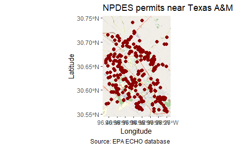

```r
library(ggplot2)
library(ggspatial)
library(dplyr)
library(sf)

## Download data as a simple feature
df <- echoWaterGetFacilityInfo(xmin = '-96.407563', ymin = '30.554395',
                                        xmax = '-96.25947', ymax = '30.751984',
                                        output = 'sf')

## Make the map
ggplot(df) +
  annotation_map_tile(zoomin = 0, progress = "none") +
  geom_sf(inherit.aes = FALSE, shape = 21,
          color = "darkred", fill = "darkred",
          size = 2) +
  labs(x = "Longitude", y = "Latitude",
       title = "NPDES permits near Texas A&M",
       caption = "Source: EPA ECHO database")
```